# Project: TMDb movie data

- Introduction
- Data Wrangling
- Exploratory Data Analysis
- Conclusions

## Introduction

### Dataset Description

This data set contains information about 10,000 movies collected from The Movie Database (TMDb), including user ratings and revenue. There are 21 features and 10866 samples available in the dataset. The features are 'id', 'imdb_id', 'popularity', 'budget', 'revenue', 'original_title', 'cast', 'homepage', 'director', 'tagline', 'keywords', 'overview','runtime', 'genres', 'production_companies', 'release_date', 'vote_count', 'vote_average', 'release_year', 'budget_adj','revenue_adj

### Question(s) for Analysis

In this project we will be analysing movies and how features such as budget and vote count determines revenue, and popularity.

### Import statements for all of the packages that will be used.

```python
import pandas as pd
import numpy as np
import matplotlib.pyplot as plt
import seaborn as sns
%matplotlib inline
```

### Loading data

```python
data = pd.read_csv('C:/Users/Hp/Downloads/tmdb-movies.csv')
```

### This is used to list out the features in the dataset as listed is the dataset description above.

```python
data.columns
```

```
Index(['id', 'imdb_id', 'popularity', 'budget', 'revenue', 'original_title',
       'cast', 'homepage', 'director', 'tagline', 'keywords', 'overview',
       'runtime', 'genres', 'production_companies', 'release_date',
       'vote_count', 'vote_average', 'release_year', 'budget_adj',
       'revenue_adj'],
      dtype='object')
```

### Perform operations to inspect data types and look for instances of missing or possibly errant data.

```python
data.head()
```

|  | id | imdb_id | popularity | budget | revenue | original_title | cast | homepage | director | tagline | ... | overview | runtime | genres | production_companies | release_date | vote_count | vote_average | release_year | budget_adj | revenue_adj |
| --- | --- | --- | --- | --- | --- | --- | --- | --- | --- | --- | --- | --- | --- | --- | --- | --- | --- | --- | --- | --- | --- |
| 0 | 135397 | tt0369610 | 32.985763 | 150000000 | 1513528810 | Jurassic World | Chris Pratt\|Bryce Dallas Howard\|Irrfan Khan\|Vi... | http://www.jurassicworld.com/ | Colin Trevorrow | The park is open. | ... | Twenty-two years after the events of Jurassic ... | 124 | Action\|Adventure\|Science Fiction\|Thriller | Universal Studios\|Amblin Entertainment\|Legenda... | 6/9/15 | 5562 | 6.5 | 2015 | 1.379999e+08 | 1.392446e+09 |
| 1 | 76341 | tt1392190 | 28.419936 | 150000000 | 378436354 | Mad Max: Fury Road | Tom Hardy\|Charlize Theron\|Hugh Keays-Byrne\|Nic... | http://www.madmaxmovie.com/ | George Miller | What a Lovely Day. | ... | An apocalyptic story set in the furthest reach... | 120 | Action\|Adventure\|Science Fiction\|Thriller | Village Roadshow Pictures\|Kennedy Miller Produ... | 5/13/15 | 6185 | 7.1 | 2015 | 1.379999e+08 | 3.481613e+08 |
| 2 | 262500 | tt2908446 | 13.112507 | 110000000 | 295238201 | Insurgent | Shailene Woodley\|Theo James\|Kate Winslet\|Ansel... | http://www.thedivergentseries.movie/#insurgent | Robert Schwentke | One Choice Can Destroy You | ... | Beatrice Prior must confront her inner demons ... | 119 | Adventure\|Science Fiction\|Thriller | Summit Entertainment\|Mandeville Films\|Red Wago... | 3/18/15 | 2480 | 6.3 | 2015 | 1.012000e+08 | 2.716190e+08 |
| 3 | 140607 | tt2488496 | 11.173104 | 200000000 | 2068178225 | Star Wars: The Force Awakens | Harrison Ford\|Mark Hamill\|Carrie Fisher\|Adam D... | http://www.starwars.com/films/star-wars-episod... | J.J. Abrams | Every generation has a story. | ... | Thirty years after defeating the Galactic Empi... | 136 | Action\|Adventure\|Science Fiction\|Fantasy | Lucasfilm\|Truenorth Productions\|Bad Robot | 12/15/15 | 5292 | 7.5 | 2015 | 1.839999e+08 | 1.902723e+09 |
| 4 | 168259 | tt2820852 | 9.335014 | 190000000 | 1506249360 | Furious 7 | Vin Diesel\|Paul Walker\|Jason Statham\|Michelle ... | http://www.furious7.com/ | James Wan | Vengeance Hits Home | ... | Deckard Shaw seeks revenge against Dominic Tor... | 137 | Action\|Crime\|Thriller | Universal Pictures\|Original Film\|Media Rights ... | 4/1/15 | 2947 | 7.3 | 2015 | 1.747999e+08 | 1.385749e+09 |

5 rows × 21 columns

```python
data.describe()
```

|  | id | popularity | budget | revenue | runtime | vote_count | vote_average | release_year | budget_adj | revenue_adj |
| --- | --- | --- | --- | --- | --- | --- | --- | --- | --- | --- |
| count | 10866.000000 | 10866.000000 | 1.086600e+04 | 1.086600e+04 | 10866.000000 | 10866.000000 | 10866.000000 | 10866.000000 | 1.086600e+04 | 1.086600e+04 |
| mean | 66064.177434 | 0.646441 | 1.462570e+07 | 3.982332e+07 | 102.070863 | 217.389748 | 5.974922 | 2001.322658 | 1.755104e+07 | 5.136436e+07 |
| std | 92130.136561 | 1.000185 | 3.091321e+07 | 1.170035e+08 | 31.381405 | 575.619058 | 0.935142 | 12.812941 | 3.430616e+07 | 1.446325e+08 |
| min | 5.000000 | 0.000065 | 0.000000e+00 | 0.000000e+00 | 0.000000 | 10.000000 | 1.500000 | 1960.000000 | 0.000000e+00 | 0.000000e+00 |
| 25% | 10596.250000 | 0.207583 | 0.000000e+00 | 0.000000e+00 | 90.000000 | 17.000000 | 5.400000 | 1995.000000 | 0.000000e+00 | 0.000000e+00 |
| 50% | 20669.000000 | 0.383856 | 0.000000e+00 | 0.000000e+00 | 99.000000 | 38.000000 | 6.000000 | 2006.000000 | 0.000000e+00 | 0.000000e+00 |
| 75% | 75610.000000 | 0.713817 | 1.500000e+07 | 2.400000e+07 | 111.000000 | 145.750000 | 6.600000 | 2011.000000 | 2.085325e+07 | 3.369710e+07 |
| max | 417859.000000 | 32.985763 | 4.250000e+08 | 2.781506e+09 | 900.000000 | 9767.000000 | 9.200000 | 2015.000000 | 4.250000e+08 | 2.827124e+09 |

### Checking for duplicates

```python
data.duplicated()
```

```
0        False
1        False
2        False
3        False
4        False
         ...
10861    False
10862    False
10863    False
10864    False
10865    False
Length: 10866, dtype: bool
```

### Checking for missing values

```python
data.isna().sum()
```

```
id                         0
imdb_id                   10
popularity                 0
budget                     0
revenue                    0
original_title             0
cast                      76
homepage                7930
director                  44
tagline                 2824
keywords                1493
overview                   4
runtime                    0
genres                    23
production_companies    1030
release_date               0
vote_count                 0
vote_average               0
release_year               0
budget_adj                 0
revenue_adj                0
dtype: int64
```

### Dropping all non important fixtures with empty values.

```python
data.drop(['cast', 'imdb_id', 'homepage', 'director', 'tagline',
           'keywords', 'overview', 'genres', 'production_companies'], axis=1, inplace=True)
```

### Confirming if all missing values have been dropped.

```python
data.isnull().sum()
```

```
id                0
popularity        0
budget            0
revenue           0
original_title    0
runtime           0
release_date      0
vote_count        0
vote_average      0
release_year      0
budget_adj        0
revenue_adj       0
dtype: int64
```

### Checking the cleaned data info.

```python
data.info()
```

```
<class 'pandas.core.frame.DataFrame'>
RangeIndex: 10866 entries, 0 to 10865
Data columns (total 12 columns):
 #   Column          Non-Null Count  Dtype
---  ------          --------------  -----
 0   id              10866 non-null  int64
 1   popularity      10866 non-null  float64
 2   budget          10866 non-null  int64
 3   revenue         10866 non-null  int64
 4   original_title  10866 non-null  object
 5   runtime         10866 non-null  int64
 6   release_date    10866 non-null  object
 7   vote_count      10866 non-null  int64
 8   vote_average    10866 non-null  float64
 9   release_year    10866 non-null  int64
 10  budget_adj      10866 non-null  float64
 11  revenue_adj     10866 non-null  float64
dtypes: float64(4), int64(6), object(2)
memory usage: 1018.8+ KB
```

```python
data.isna().sum()
```

```
id                0
popularity        0
budget            0
revenue           0
original_title    0
runtime           0
release_date      0
vote_count        0
vote_average      0
release_year      0
budget_adj        0
revenue_adj       0
dtype: int64
```

### Getting the mean of each feature.

```python
data.mean()
```

```
id              6.606418e+04
popularity      6.464410e-01
budget          1.462570e+07
revenue         3.982332e+07
runtime         1.020709e+02
vote_count      2.173897e+02
vote_average    5.974922e+00
release_year    2.001323e+03
budget_adj      1.755104e+07
revenue_adj     5.136436e+07
dtype: float64
```

### How movies budget affects the movies revenue using the mean.

**The mean of budget is 1.462570e+07**

```python
low_budget = data[data['budget'] < 1.462570e+07]
high_budget = data[data['budget'] >= 1.462570e+07]
```

**The mean of low budget movies revenue.**

```python
lbudget_revenue_mean = low_budget['revenue'].mean()
lbudget_revenue_mean
```

```
7505623.702695925
```

**The mean of high budget movies revenue.**

```python
hbudget_revenue_mean = high_budget['revenue'].mean()
hbudget_revenue_mean
```

```
128973657.50466967
```

### Differnecence between high and low budget movies revenue mean.

```python
hbudget_revenue_mean - lbudget_revenue_mean
```

```
121468033.80197375
```

### Movies with high budgets generally have a high revenue compared to movies with low budgets.

> **Note:** In this dataset, low_budget movies have more samples than high_budget movies.

### Creating function for visualisation.

```python
def label(x, y, t):
    plt.xlabel(x)
    plt.ylabel(y)
    plt.title(t)
```

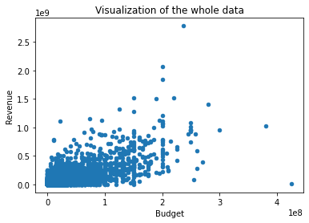

```python
data.plot(x="budget", y= "revenue", kind="scatter")
label("Budget", "Revenue", "Visualization of the whole data")
```

##### This scatter plot shows that there is a positive correlation between Budget and Revenue.

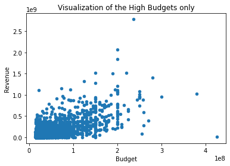

```python
high_budget.plot(x="budget", y="revenue", kind="scatter")
label("Budget", "Revenue", "Visualization of the High Budgets only")
```

##### The higher the budget, the higher the revenue tends to be.

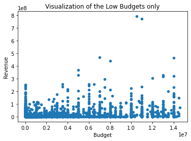

```python
low_budget.plot(x="budget", y="revenue", kind="scatter");
label("Budget", "Revenue", "Visualization of the Low Budgets only")
```

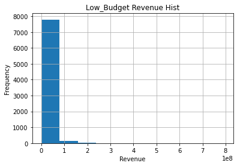

```python
low_budget.revenue.hist()
label("Revenue", "Frequency", "Low_Budget Revenue Hist")
```

##### Most of the low_budget revenue is between 0 and approximately 90 million.

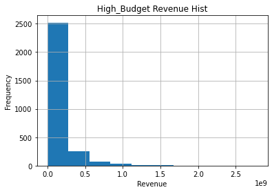

```python
high_budget.revenue.hist()
label("Revenue", "Frequency", "High_Budget Revenue Hist")
```

##### The high_budget revenue is skewed to the right.

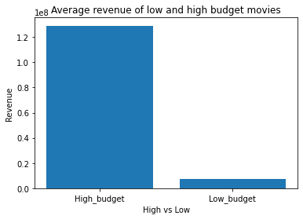

```python
plt.bar(["High_budget", "Low_budget"], [hbudget_revenue_mean, lbudget_revenue_mean])
label("High vs Low", "Revenue", "Average revenue of low and high budget movies")
```

##### Although the samples for low budget movies is higher than the samples for high budget movies. High budget movies generates more revenue than low budget movies

### The effect of vote count on movies popularity.

```python
#The mean of vote count is 2.173897e+02
low_vote_count = data[data['vote_count'] < 2.173897e+02]
high_vote_count = data[data['vote_count'] >= 2.173897e+02]
```

```python
#The mean of low vote count movies popularity.
lowVC_Pmean = low_vote_count['popularity'].mean()
lowVC_Pmean
```

```
0.3703528157894719
```

```python
#The mean of high vote count movies popularity.
highVC_Pmean = high_vote_count['popularity'].mean()
highVC_Pmean
```

```
1.8071218232758604
```

```python
#Differnecence between high and low vote count movies popularity mean.
highVC_Pmean - lowVC_Pmean
```

```
1.4367690074863884
```

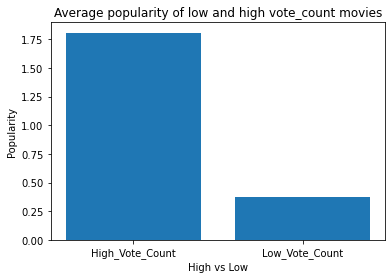

```python
plt.bar(["High_Vote_Count", "Low_Vote_Count"], [highVC_Pmean, lowVC_Pmean])
label("High vs Low", "Popularity", "Average popularity of low and high vote_count movies")
```

#### Movies with high vote counts are more popular than movies with low vote count.

### The effect of budget on movies popularity

```python
#How budget affects popularity
low_budget = data[data['budget'] < 1.462570e+07]
high_budget = data[data['budget'] >= 1.462570e+07]
```

```python
lowB_Pmean = low_budget['popularity'].mean()
lowB_Pmean
```

```
0.40399253479623665
```

```python
highB_Pmean = high_budget['popularity'].mean()
highB_Pmean
```

```
1.3152497125562082
```

```python
#Differnecence between high and low budget movies popularity  mean.
highB_Pmean - lowB_Pmean
```

```
0.9112571777599715
```

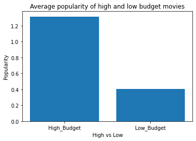

```python
plt.bar(["High_Budget", "Low_Budget"], [highB_Pmean, lowB_Pmean])
label("High vs Low", "Popularity", "Average popularity of high and low budget movies")
```

## Conclusions

> **1**: Movies with high budgets generally have a high revenue compared to movies with low budgets. The higher the budget, the higher the revenue tends to be. Note: In this dataset, low_budget movies have more samples than high_budget movies.

> **2**: Although movies with high vote counts are more popular. High vote count movies are more popular than movies with a low vote count.

> **3**: Movies budget also contributes to the popularity of the movie. The average of the movies with high budgets is more popular than the mean of movies with low budgets.

## Limitation

> **1**: The sample size of the low budget movies is far greater than the available sample for high budgets movies and I think it will be more reasonable for the samples to be of the same proportion or at least very close.